# Final Data Analysis Project Guide

**For SMASH Computer Science Fundamentals II: Data Analysis**  
This guide assumes your class has already covered matplotlib, numpy, and SQL basics.  
Here, I'll show you how to bring all three together to analyze data within a Pokemon database.  
This should give you an idea of what your final project should contain.  
The notes I write between chunks of code are examples of how you could talk through your program for your video or presentation.  
Here is the complete program this guide references:  
https://github.com/ahob85/smash/blob/master/cs2/final/final.py

## Import libraries

These libraries are essential.

```python
import matplotlib.pyplot as plt
import numpy as np
import sqlite3
import csv
```

## Create/Connect to a SQL database, and assign a "cursor"

"cur" simply refers to the thing that will be doing the fetching and inserting in database for us.  
You can imagine it like a little robot scurrying all over the database, following our every command.

```python
conn = sqlite3.connect("pokebase.sqlite3")
cur = conn.cursor()
```

## Create a table

This table reflects the structure of the data in the CSV file.  
Here we are simply specifying the columns (i.e., attributes) of the table.  
Keep in mind that each record or "row" in our table is actually a **tuple**.  
This will be tremendously helpful to us in a bit.

```python
cur.execute("DROP TABLE IF EXISTS Pokedex")
cur.execute("CREATE TABLE Pokedex ("
            "id INTEGER PRIMARY KEY, "
            "name TEXT, "
            "type1 TEXT, "
            "type2 TEXT, "
            "total INTEGER, "
            "hp INTEGER, "
            "attack INTEGER, "
            "defense INTEGER, "
            "spatk INTEGER, "
            "spdef INTEGER, "
            "speed INTEGER, "
            "generation INTEGER, "
            "legendary INTEGER)")
```

```
<sqlite3.Cursor at 0x7f0965afa810>
```

## Import CSV data into table

Make sure your CSV file is in the same directory as your Python file.  
Here we are simply inserting all rows from the CSV using a for-each loop.  
Remember, the rows are tuples. So the very first element of a row (row[0]) represents that record's id number.

```python
file = open("Pokemon.csv")
csv_file = csv.reader(file)
for row in csv_file:
    cur.execute("INSERT INTO Pokedex VALUES (?, ?, ?, ?, ?, ?, ?, ?, ?, ?, ?, ?, ?)",
                (row[0], row[1], row[2], row[3], row[4], row[5], row[6], row[7], row[8], row[9], row[10], row[11], row[12]))

conn.commit()
```

## Test your table

Let's test the integrity of our table by printing a few records.

```python
cur.execute("SELECT * FROM Pokedex LIMIT 10;")
for row in cur:
    print(row)
```

```
(1, 'Bulbasaur', 'Grass', 'Poison', 318, 45, 49, 49, 65, 65, 45, 1, 0)
(2, 'Ivysaur', 'Grass', 'Poison', 405, 60, 62, 63, 80, 80, 60, 1, 0)
(3, 'Venusaur', 'Grass', 'Poison', 525, 80, 82, 83, 100, 100, 80, 1, 0)
(4, 'VenusaurMega Venusaur', 'Grass', 'Poison', 625, 80, 100, 123, 122, 120, 80, 1, 0)
(5, 'Charmander', 'Fire', '', 309, 39, 52, 43, 60, 50, 65, 1, 0)
(6, 'Charmeleon', 'Fire', '', 405, 58, 64, 58, 80, 65, 80, 1, 0)
(7, 'Charizard', 'Fire', 'Flying', 534, 78, 84, 78, 109, 85, 100, 1, 0)
(8, 'CharizardMega Charizard X', 'Fire', 'Dragon', 634, 78, 130, 111, 130, 85, 100, 1, 0)
(9, 'CharizardMega Charizard Y', 'Fire', 'Flying', 634, 78, 104, 78, 159, 115, 100, 1, 0)
(10, 'Squirtle', 'Water', '', 314, 44, 48, 65, 50, 64, 43, 1, 0)
```

## Create a function to compute stuff for you

Let the computer do all the hard work while you sit back and chill.  
We'll first write a function that returns the mean of a list of values, rounded to the nearest hundreth decimal place.  
This will come in handy soon.

```python
def get_mean(nums):
    if(len(nums) == 0):
        return 0
    else:
        total = 0
        for num in nums:
            total += num
        return round(total / len(nums), 2)
```

## Bring table data into Python

We will test our get_mean() function with data from our table.  
But first let's see what kind of thing is returned from a simple SELECT query.

```python
cur.execute("SELECT hp FROM Pokedex LIMIT 5")
for row in cur:
    print(row)
```

```
(45,)
(60,)
(80,)
(80,)
(39,)
```

Looks like SELECT returns tuples. Just as we said before, records are just tuples.  
This means if we want to access the integer values themselves, we would do so the same way we would with tuple or list.  
In this case, each tuple above contains only one element (since I asked only for HP).  
So the the info I want is at index 0.

```python
cur.execute("SELECT hp FROM Pokedex WHERE name = 'Pikachu';")
data = cur.fetchone()[0]
print(data)
print(type(data))
```

```
35
<class 'int'>
```

## Test your function

Now we can test our get_mean() function with some data from our table.

```python
cur.execute("SELECT hp FROM Pokedex")
hp_data = []
for row in cur:
    hp_data.append(row[0])
hp_mean = get_mean(hp_data)
print("HP mean = ", hp_mean)
```

```
HP mean =  69.26
```

I wonder... is the average HP for non-Legendary Pokemon less than that for Legendary Pokemon?

```python
cur.execute("SELECT hp FROM Pokedex WHERE Legendary = 0")
nonlegendary_hp = []
for row in cur:
    nonlegendary_hp.append(row[0])
cur.execute("SELECT hp FROM Pokedex WHERE Legendary = 1")
legendary_hp = []
for row in cur:
    legendary_hp.append(row[0])
print("Non-Legendary HP mean =", get_mean(nonlegendary_hp))
print("Legendary HP mean =", get_mean(legendary_hp))
```

```
Non-Legendary HP mean = 67.18
Legendary HP mean = 92.74
```

Yeah, that makes sense.

## Write and test another function

Let's write a function that returns the standard devation of a list of numbers, rounded to the nearest hundreth decimal place.

```python
def get_sd(nums):
    mean = get_mean(nums)
    total = 0
    for num in nums:
        total += (num - mean) ** 2
    variance = total / (len(nums) - 1)
    return round(variance ** 0.5, 2)

hp_sd = get_sd(hp_data)
print("HP standard deviation =", hp_sd)
```

```
HP standard deviation = 25.53
```

## Make a histogram

Let's use matplotlib to make a histogram of Pokemon hp.  
This will help us see how hp is distributed among all the Pokeymans.

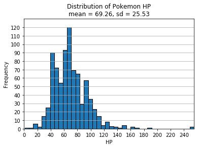

```python
plt.figure(3)
plt.title("Distribution of Pokemon HP\nmean = {}, sd = {}".format(hp_mean, hp_sd))
plt.xlabel("HP")
plt.ylabel("Frequency")
plt.hist(hp_data, bins="auto", edgecolor="black")
plt.axis([min(hp_data), max(hp_data), 0, 130])
plt.xticks(list(range(0, max(hp_data), 20)))
plt.yticks(list(range(0, 130, 10)))
plt.grid(axis="y")
plt.show()
```

This looks **positively skewed**.  
There are **outliers** toward the right, especially that one or two waaaaay out there.

```python
print(max(hp_data))
```

```
255
```

Which Pokemon has 255 base HP?

```python
cur.execute("SELECT name FROM Pokedex WHERE hp = 255")
print(cur.fetchone()[0])
```

```
Blissey
```

WHAT? You mean this cute lil pudgeball has the most hp out of all the Pokemon? Guess so!

[figure not shown]

## Make a scatter plot

I want to examine the relationship between defense and speed.  
According to EDA philosophy, it's good to get a visual before I run stats. This gives me a "feel" for the data that numbers might not provide.  
My hunch is that Pokemon with a lot of defense are generally slow. So the two variables should be **negatively correlated**.  
But I won't know until I see it for myself.

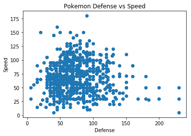

```python
cur.execute("SELECT defense,speed FROM Pokedex")
d_data, s_data = [], []
for row in cur:
    d_data.append(row[0])
    s_data.append(row[1])
plt.figure(2)
plt.title("Pokemon Defense vs Speed")
plt.xlabel("Defense")
plt.ylabel("Speed")
plt.scatter(d_data, s_data)
plt.show()
```

Hmm... hard to see any kind of correlation here, at least with my own two eyes.  
Time to break out the numpy library.

## Find Pearson correlation coefficient (r) between two variables

It's easy with numpy.

```python
correlation = np.corrcoef(d_data, s_data)
print(correlation)
```

```
[[ 1.         0.0152266]
 [ 0.0152266  1.       ]]
```

Uh... what is this?  
Well that's actually a matrix containing all combinations of r coefficients for the two datasets entered.  
Half of them are identical since each dataset is compared to the other, as well as itself (yielding an r of 1.0).  
Here is an image to give you a better idea.

[figure not shown]

Let's access one of those valid r coefficients and round it off to two decimal places.

```python
correlation = round(np.corrcoef(d_data, s_data)[0][1], 2)
print("Pearson's r =", correlation)
```

```
Pearson's r = 0.02
```

Our r coefficient is about 0.02. This means the relationship is pretty much nonexistant.  
Or more properly, we'd say **defense does not predict speed (and vice versa)**.  
My hunch was wrong!

## Make another scatter plot

Let's try something else. I'll see if there is a relationship between attack power and HP.  
Let's take a look!

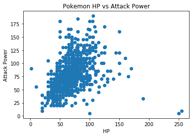

```python
a_data = []
cur.execute("SELECT attack FROM Pokedex")
for row in cur:
    a_data.append(row[0])
plt.figure(3)
plt.title("Pokemon HP vs Attack Power")
plt.xlabel("HP")
plt.ylabel("Attack Power")
plt.scatter(hp_data, a_data)
plt.show()
```

Looks like there is a relationship!  
There are a few **outliers** toward the right end.  
These are Pokemon with high HP but almost no attack power, one of whom is probably Blissey!  
Let's calculate r for these two variables.

```python
correlation = round(np.corrcoef(hp_data, a_data)[0][1], 2)
print("Pearson's r =", correlation)
```

```
Pearson's r = 0.42
```

So we got a 0.42 on this one, which indicates a moderately positive relationship between the two variables.  
Those outliers are very likely throwing this off a tad... but hey, that's Pokemon for you. Gotta catch 'em all, even the weird ones.

## Create a model

Now that we have identified at least a moderate relationship between two variables, we can think about regression.  
The scatter plot we made appears to follow a linear (y = ax + b) model, doesn't it?  
So let's make one with numpy and see how it fits.

```python
model = np.polyfit(hp_data, a_data, deg=1)
print(model)
```

```
[  0.53689898  41.81629745]
```

np.polyfit() returns a list-like structure containing the coefficients and constants of an equation, based on what we entered for "deg" or *degree*.  
We anticipate a linear or "first degree" equation, so we entered "1" as the value for "deg". [More on equation degrees here.](http://www.tpub.com/math1/12a.htm)  
So our regression equation would look like this:  
**y = 0.54x + 41.82**

## Plot the model onto the data

Now let's plot the model onto the data to judge how well it fits with our eyes.

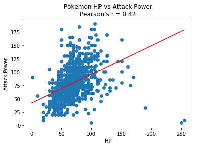

```python
x_range = list(range(max(hp_data))) # Just creates a list of integers from 0 to highest HP value in dataset
p = np.poly1d(model)                # the function p sets up the y = ax + b equation for the next step
y_range = p(x_range)                # for every value in x_range, multiply by a and add b (from our model)
plt.figure(4)
plt.title("Pokemon HP vs Attack Power\nPearson's r = {}".format(correlation))
plt.xlabel("HP")
plt.ylabel("Attack Power")
plt.scatter(hp_data, a_data)
plt.plot(x_range, y_range, color="red") # here's where we draw the line (no pun intended)
plt.show()
```

Well, what do you think? Does this linear model fit the data well?  
As you learn more and more math, you'll find different ways to model your data, which can help you not only find relationships between variables, but predict future outcomes. Whoa... that's pretty cool huh?

# If you have this much, you're done.

Just be sure to record a video of you demonstraing your program in action Oh, and of course, don't forget to close your connection to the database.

```python
conn.close()
```